# Assess pLGG survival by BRAF fusion breakpoint fusion type in PBTA ancestry cohort

Ryan Corbett

2024

Load libraries and set directories

```r
library(data.table)
library(tidyverse)
```

```r
library(survival)
library(patchwork)

root_dir <- rprojroot::find_root(rprojroot::has_dir(".git"))

data_dir <- file.path(root_dir, "data")
analysis_dir <- file.path(root_dir, "analyses", "braf-fusions")
results_dir <- file.path(analysis_dir, "results")
input_dir <- file.path(analysis_dir, "input")
plot_dir <- file.path(analysis_dir, "plots")

source(file.path(root_dir, "analyses", "survival", "util", "survival_models_interaction.R"))
```

Define file paths

```r
hist_file <- file.path(results_dir, "lgg-braf-fusion-breakpoint-annotation.tsv")
```

Load hist file with breakpoint data, and define `breakpoint_type` and `breakpoint_group` columns

```r
braf_hist <- read_tsv(hist_file)
braf_hist <- braf_hist %>%
  # Because we noticed different breakpoint frequencies in Asian vs. other ancestries, we will define a column that merges asian ancestries and retain other predicted ancestries
  dplyr::mutate(AS_ancestry = case_when(
    predicted_ancestry %in% c("EAS", "SAS") ~ "AS",
    TRUE ~ predicted_ancestry
  )) %>%
  dplyr::mutate(breakpoint_group = fct_relevel(breakpoint_group,
                                               c("16:11", "15:09", "16:09", "18:10", "rare")))
```

Run Kaplan-Meier analysis of event-free survival by breakpoint type (common vs. rare)

```r
kap_efs_type <- survival_analysis(
  metadata  = braf_hist,
  ind_var = "breakpoint_type",
  test = "kap.meier",
  metadata_sample_col = "Kids_First_Biospecimen_ID",
  days_col = "EFS_days",
  status_col = "EFS_status"
  )
```

```
## Testing model: survival::Surv(EFS_days, EFS_status) ~ breakpoint_type with kap.meier
```

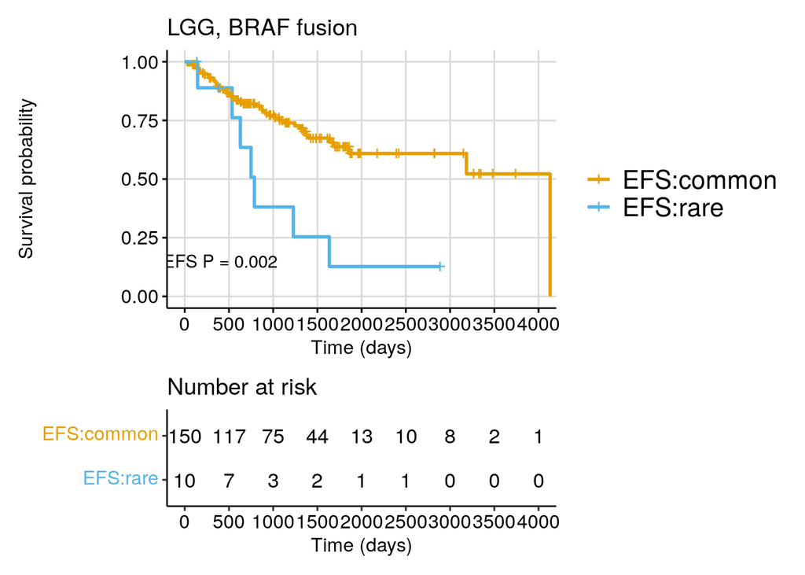

```r
km_plot_type <- plotKM(model = kap_efs_type,
                    variable = "breakpoint_type",
                    combined = F,
                    title = "LGG, BRAF fusion")

km_plot_type
```

```r
ggsave(file.path(plot_dir, "pbta_ancestry_km_efs_breakpoint_type.pdf"),
       width = 7.5, height = 5)
```

Run Kaplan-Meier analysis of event-free survival by breakpoint group

```r
kap_efs_group <- survival_analysis(
  metadata  = braf_hist,
  ind_var = "breakpoint_group",
  test = "kap.meier",
  metadata_sample_col = "Kids_First_Biospecimen_ID",
  days_col = "EFS_days",
  status_col = "EFS_status"
  )
```

```
## Testing model: survival::Surv(EFS_days, EFS_status) ~ breakpoint_group with kap.meier
```

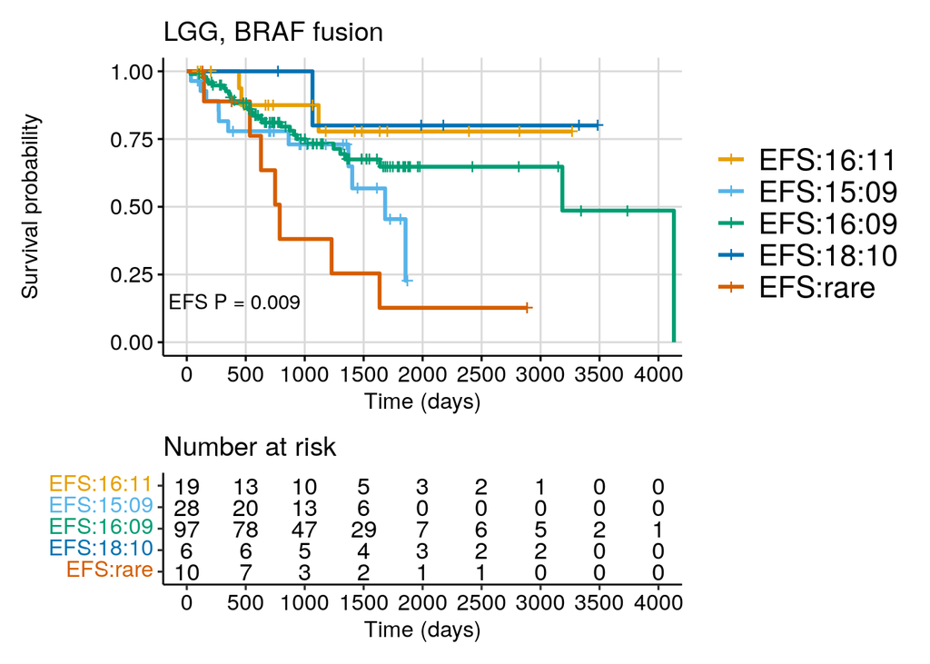

```r
km_plot_group <- plotKM(model = kap_efs_group,
                    variable = "breakpoint_group",
                    combined = F,
                    title = "LGG, BRAF fusion")

km_plot_group
```

```r
ggsave(file.path(plot_dir, "pbta_ancestry_km_efs_breakpoint_group.pdf"),
       width = 7.5, height = 5)
```

Run Kaplan-Meier analysis of event-free survival by predicted ancestry among 16:9 breakpoint pts

```r
kap_efs_group <- survival_analysis(
  metadata  = braf_hist[braf_hist$breakpoint_group == "16:09" & !braf_hist$predicted_ancestry %in% c("EAS", "SAS"),],
  ind_var = "predicted_ancestry",
  test = "kap.meier",
  metadata_sample_col = "Kids_First_Biospecimen_ID",
  days_col = "EFS_days",
  status_col = "EFS_status"
  )
```

```
## Testing model: survival::Surv(EFS_days, EFS_status) ~ predicted_ancestry with kap.meier
```

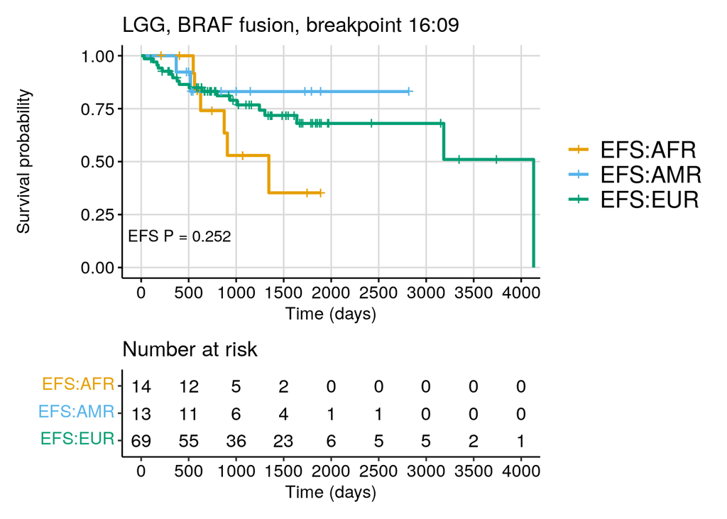

```r
km_plot_group <- plotKM(model = kap_efs_group,
                    variable = "predicted_ancestry",
                    combined = F,
                    title = "LGG, BRAF fusion, breakpoint 16:09")

km_plot_group
```

```r
ggsave(file.path(plot_dir, "pbta_ancestry_km_efs_16_9_predicted_ancestry.pdf"),
       width = 7.5, height = 5)
```

Run Kaplan-Meier analysis of event-free survival by predicted ancestry among 15:9 breakpoint pts (combine asian ancestries here)

```r
kap_efs_group <- survival_analysis(
  metadata  = braf_hist[braf_hist$breakpoint_group == "15:09",],
  ind_var = "AS_ancestry",
  test = "kap.meier",
  metadata_sample_col = "Kids_First_Biospecimen_ID",
  days_col = "EFS_days",
  status_col = "EFS_status"
  )
```

```
## Testing model: survival::Surv(EFS_days, EFS_status) ~ AS_ancestry with kap.meier
```

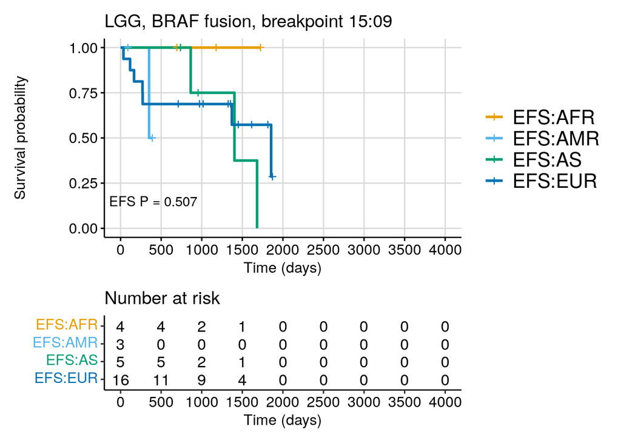

```r
km_plot_group <- plotKM(model = kap_efs_group,
                    variable = "AS_ancestry",
                    combined = F,
                    title = "LGG, BRAF fusion, breakpoint 15:09")

km_plot_group
```

```r
ggsave(file.path(plot_dir, "pbta_ancestry_km_efs_15_9_predicted_ancestry.pdf"),
       width = 7.5, height = 5)
```

Run and plot cox proportional hazards model of EFS including tumor resection and breakpoint type as covariates

Interaction model:

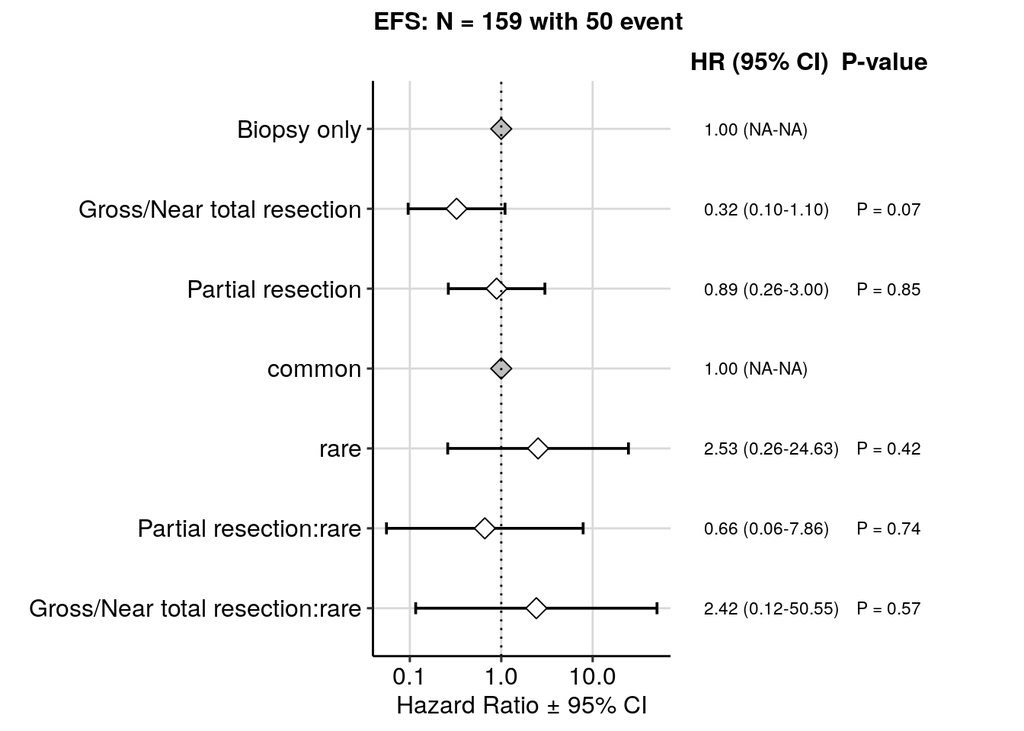

```r
braf_model_efs <- fit_save_model(braf_hist[braf_hist$extent_of_tumor_resection != "Not Reported",],
                                    terms = "extent_of_tumor_resection*breakpoint_type",
               file.path(results_dir, "coxph_braf_efs_int_resection_breakpoint_type.RDS"),
               "multivariate",
               years_col = "EFS_years", status_col = "EFS_status"
              )

plotForest(readRDS(file.path(results_dir, "coxph_braf_efs_int_resection_breakpoint_type.RDS")))
```

```r
ggsave(file.path(plot_dir, "pbta_ancestry_forest_efs_int_resection_breakpoint_type.pdf"),
       width = 8, height = 3)
```

Additive model:

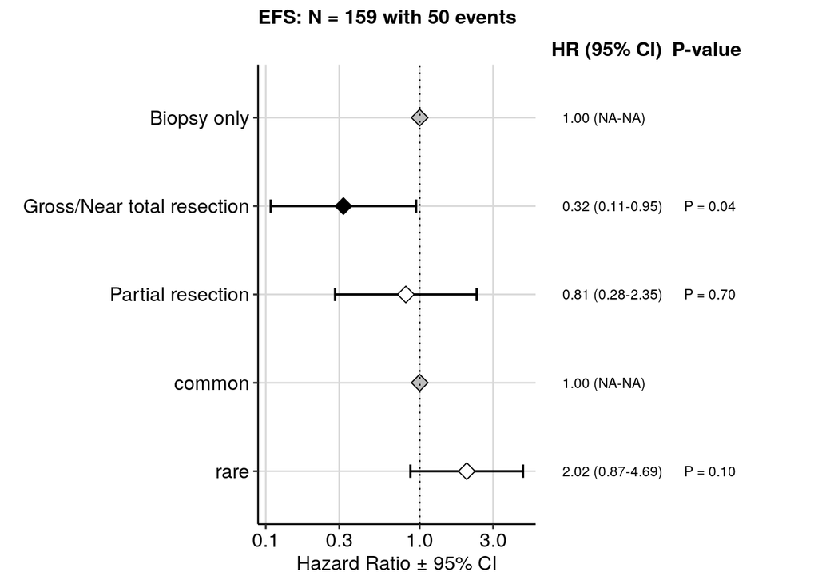

```r
braf_model_efs <- fit_save_model(braf_hist[braf_hist$extent_of_tumor_resection != "Not Reported",],
                                    terms = "extent_of_tumor_resection+breakpoint_type",
               file.path(results_dir, "coxph_braf_efs_add_resection_breakpoint_type.RDS"),
               "multivariate",
               years_col = "EFS_years", status_col = "EFS_status"
              )

plotForest(readRDS(file.path(results_dir, "coxph_braf_efs_add_resection_breakpoint_type.RDS")))
```

```r
ggsave(file.path(plot_dir, "pbta_ancestry_forest_efs_add_resection_breakpoint_type.pdf"),
       width = 8, height = 3)
```

Re-run including predicted ancestry as covariate

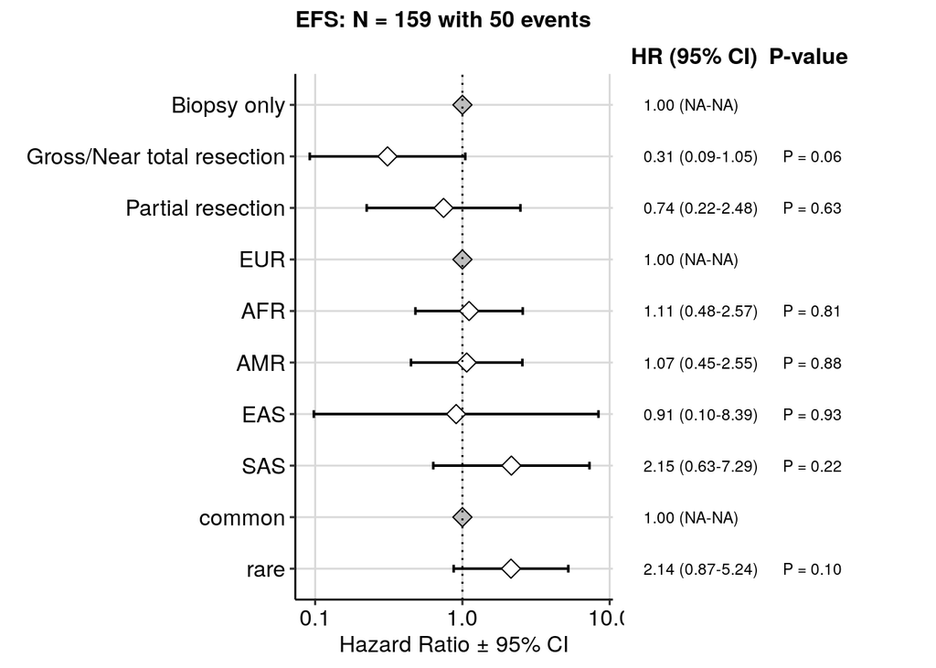

```r
braf_hist <- braf_hist %>%
  dplyr::mutate(predicted_ancestry = fct_relevel(predicted_ancestry,
                                                 c("EUR", "AFR", "AMR", "EAS", "SAS"))) %>%
  dplyr::mutate(AS_ancestry = fct_relevel(AS_ancestry,
                                                 c("EUR", "AFR", "AMR", "AS")))

braf_model_efs <- fit_save_model(braf_hist[braf_hist$extent_of_tumor_resection != "Not Reported",],
                                    terms = "extent_of_tumor_resection+predicted_ancestry+breakpoint_type",
               file.path(results_dir, "coxph_braf_efs_add_resection_ancestry_breakpoint_type.RDS"),
               "multivariate",
               years_col = "EFS_years", status_col = "EFS_status"
              )

plotForest(readRDS(file.path(results_dir, "coxph_braf_efs_add_resection_ancestry_breakpoint_type.RDS")))
```

```r
ggsave(file.path(plot_dir, "pbta_ancestry_forest_efs_add_resection_ancestry_breakpoint_type.pdf"),
       width = 8, height = 4)
```

Run and plot cox proportional hazards model of EFS including tumor resection and breakpoint group as covariates

Interaction model:

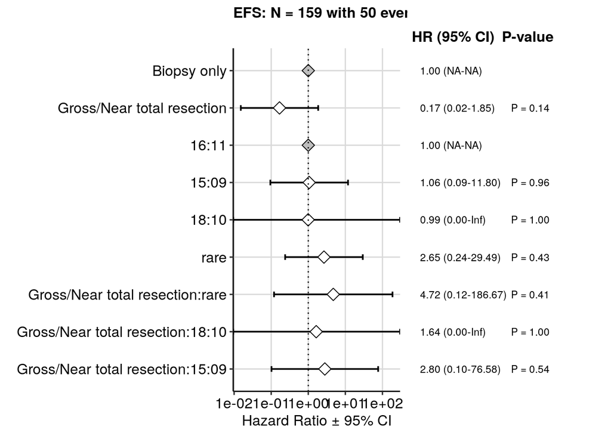

```r
braf_model_efs <- fit_save_model(braf_hist[braf_hist$extent_of_tumor_resection != "Not Reported",],
                                    terms = "extent_of_tumor_resection*breakpoint_group",
               file.path(results_dir, "coxph_braf_efs_int_resection_breakpoint_group.RDS"),
               "multivariate",
               years_col = "EFS_years", status_col = "EFS_status"
              )
plotForest(readRDS(file.path(results_dir, "coxph_braf_efs_int_resection_breakpoint_group.RDS")))
```

```r
ggsave(file.path(plot_dir, "pbta_ancestry_forest_efs_int_resection_breakpoint_group.pdf"),
       width = 8, height = 3)
```

Additive model:

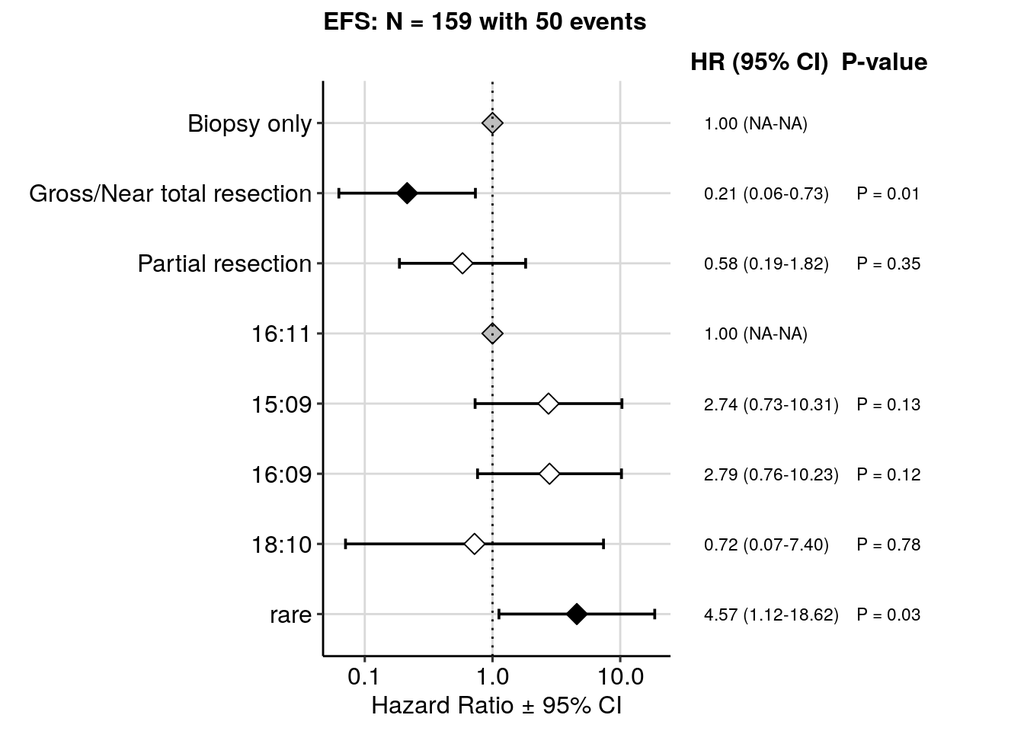

```r
braf_model_efs <- fit_save_model(braf_hist[braf_hist$extent_of_tumor_resection != "Not Reported",],
                                    terms = "extent_of_tumor_resection+breakpoint_group",
               file.path(results_dir, "coxph_braf_efs_add_resection_breakpoint_group.RDS"),
               "multivariate",
               years_col = "EFS_years", status_col = "EFS_status"
              )

plotForest(readRDS(file.path(results_dir, "coxph_braf_efs_add_resection_breakpoint_group.RDS")))
```

```r
ggsave(file.path(plot_dir, "pbta_ancestry_forest_efs_add_resection_breakpoint_group.pdf"),
       width = 8, height = 3)
```

Re-run with predicted ancestry as covariate

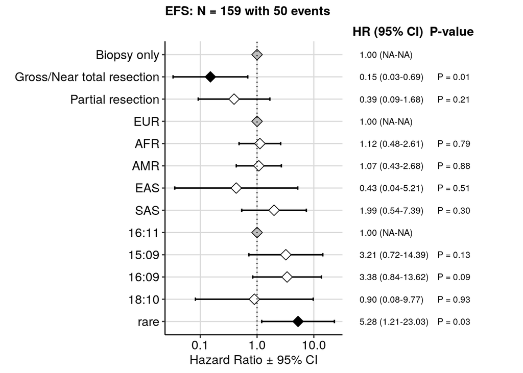

```r
braf_model_efs <- fit_save_model(braf_hist[braf_hist$extent_of_tumor_resection != "Not Reported",],
                                    terms = "extent_of_tumor_resection+predicted_ancestry+breakpoint_group",
               file.path(results_dir, "coxph_braf_efs_add_resection_ancestry_breakpoint_group.RDS"),
               "multivariate",
               years_col = "EFS_years", status_col = "EFS_status"
              )

plotForest(readRDS(file.path(results_dir, "coxph_braf_efs_add_resection_ancestry_breakpoint_group.RDS")))
```

```r
ggsave(file.path(plot_dir, "pbta_ancestry_forest_efs_add_resection_ancestry_breakpoint_group.pdf"),
       width = 8, height = 4)
```

Run and plot cox proportional hazards model of EFS in 16:09 breakpoint patients, including tumor resection and predicted ancestry as covariates

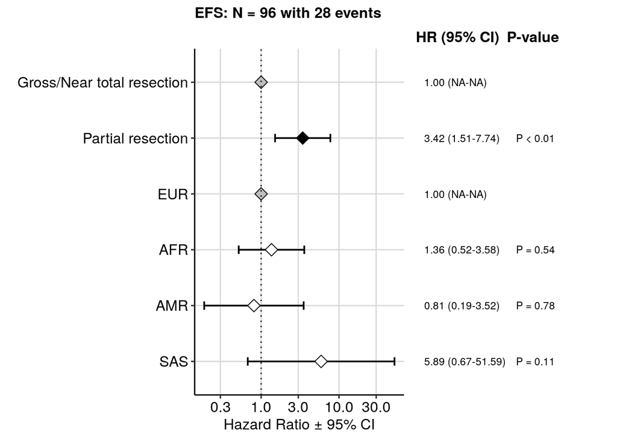

```r
braf_model_efs <- fit_save_model(braf_hist[braf_hist$extent_of_tumor_resection != "Not Reported" & braf_hist$breakpoint_group == "16:09",],
                                    terms = "extent_of_tumor_resection+predicted_ancestry",
               file.path(results_dir, "coxph_braf_efs_add_16_9_resection_ancestry_breakpoint.RDS"),
               "multivariate",
               years_col = "EFS_years", status_col = "EFS_status"
              )

plotForest(readRDS(file.path(results_dir, "coxph_braf_efs_add_16_9_resection_ancestry_breakpoint.RDS")))
```

```r
ggsave(file.path(plot_dir, "pbta_ancestry_forest_efs_add_breakpoint16_9_resection_ancestry.pdf"),
       width = 8, height = 3)
```

Run and plot cox proportional hazards model of EFS in 15:09 breakpoint patients, including tumor resection and predicted ancestry as covariates

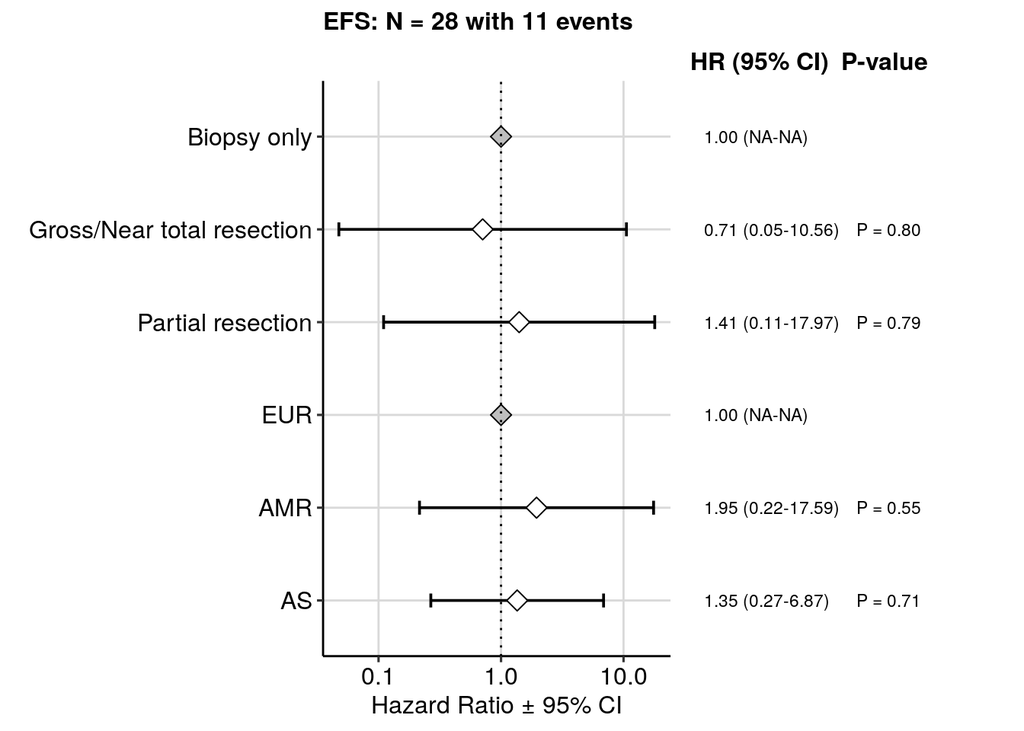

```r
braf_model_efs <- fit_save_model(braf_hist[braf_hist$extent_of_tumor_resection != "Not Reported" & braf_hist$breakpoint_group == "15:09",],
                                    terms = "extent_of_tumor_resection+AS_ancestry",
               file.path(results_dir, "coxph_braf_efs_add_15_9_resection_ancestry_breakpoint.RDS"),
               "multivariate",
               years_col = "EFS_years", status_col = "EFS_status"
              )
plotForest(readRDS(file.path(results_dir, "coxph_braf_efs_add_15_9_resection_ancestry_breakpoint.RDS")))
```

```r
ggsave(file.path(plot_dir, "pbta_ancestry_forest_efs_add_breakpoint15_9_resection_ancestry.pdf"),
       width = 8, height = 3)
```